# Lab 9. Binary logistic regression

### Libraries

```r
library(tidyverse)
library(stats) # glm() function for logit regression models
library(caret) # library to calculate confusion matrix and agreement
library(pROC) # library to draw ROC curves
```

## 1 Logit model with one numeric predictor

It is interesting to know whether the languages with more consonants are more likely to have ejective sounds. So we collected data from phonological database LAPSyD: http://goo.gl/0btfKa.

### 1.1 Data summary

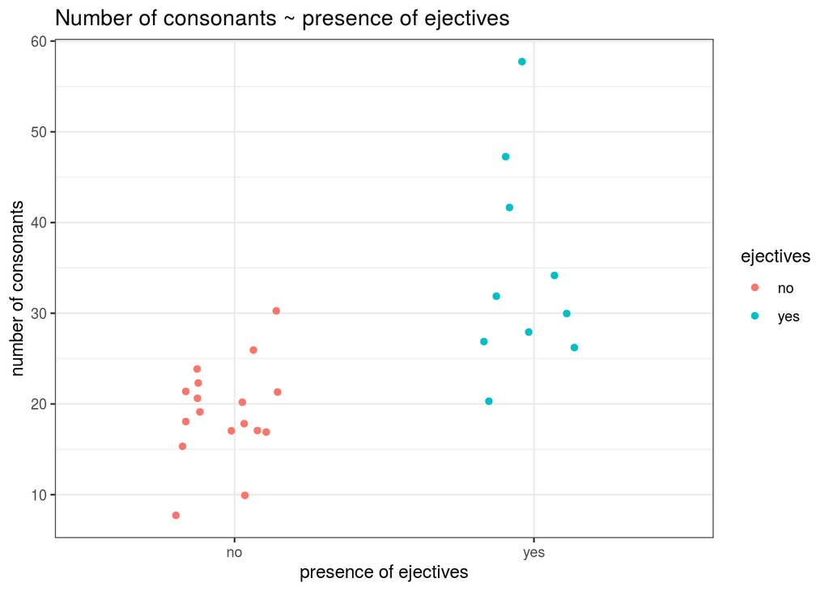

```r
ej_cons <- read.csv("https://agricolamz.github.io/2018-MAG_R_course/data/correlation_regressions_ejectives.csv")
ej_cons %>%
  ggplot(aes(ejectives, n.cons.lapsyd, color = ejectives))+
  geom_jitter(width = 0.2)+
  labs(title = "Number of consonants ~ presence of ejectives",
       x = "presence of ejectives",
       y = "number of consonants")+
  theme_bw()
```

### 1.2 Model without predictors

```r
fit1 <- glm(ejectives~1, data = ej_cons, family = "binomial")
summary(fit1)
```

```
##
## Call:
## glm(formula = ejectives ~ 1, family = "binomial", data = ej_cons)
##
## Deviance Residuals:
##     Min       1Q   Median       3Q      Max
## -0.9619  -0.9619  -0.9619   1.4094   1.4094
##
## Coefficients:
##             Estimate Std. Error z value Pr(>|z|)
## (Intercept)  -0.5306     0.3985  -1.331    0.183
##
## (Dispersion parameter for binomial family taken to be 1)
##
##     Null deviance: 35.594  on 26  degrees of freedom
## Residual deviance: 35.594  on 26  degrees of freedom
## AIC: 37.594
##
## Number of Fisher Scoring iterations: 4
```

How we get this estimate value?

```r
table(ej_cons$ejectives)
```

```
##
##  no yes
##  17  10
```

```r
log(10/17)
```

```
## [1] -0.5306283
```

What does this model say? This model says that if we have no predictors and take some language it has $\frac{1}{(1+e^{0.5306283})} = 0.37037$ probability to have ejectives.

```r
1/(1+exp(0.5306283))
```

```
## [1] 0.3703704
```

### 1.3 Model with numeric predictor

```r
fit2 <- glm(ejectives~n.cons.lapsyd, data = ej_cons, family = "binomial")
summary(fit2)
```

```
##
## Call:
## glm(formula = ejectives ~ n.cons.lapsyd, family = "binomial",
##     data = ej_cons)
##
## Deviance Residuals:
##     Min       1Q   Median       3Q      Max
## -1.8317  -0.4742  -0.2481   0.1914   2.1997
##
## Coefficients:
##               Estimate Std. Error z value Pr(>|z|)
## (Intercept)    -9.9204     3.7699  -2.631   0.0085 **
## n.cons.lapsyd   0.3797     0.1495   2.540   0.0111 *
## ---
## Signif. codes:  0 '***' 0.001 '**' 0.01 '*' 0.05 '.' 0.1 ' ' 1
##
## (Dispersion parameter for binomial family taken to be 1)
##
##     Null deviance: 35.594  on 26  degrees of freedom
## Residual deviance: 16.202  on 25  degrees of freedom
## AIC: 20.202
##
## Number of Fisher Scoring iterations: 6
```

What does this model say? This model says:

$$\log(odds(ej)) = \beta_o + \beta_1 \times n.cons.lapsyd =
-9.9204 + 0.3797 \times n.cons.lapsyd$$

Lets visualize our model:

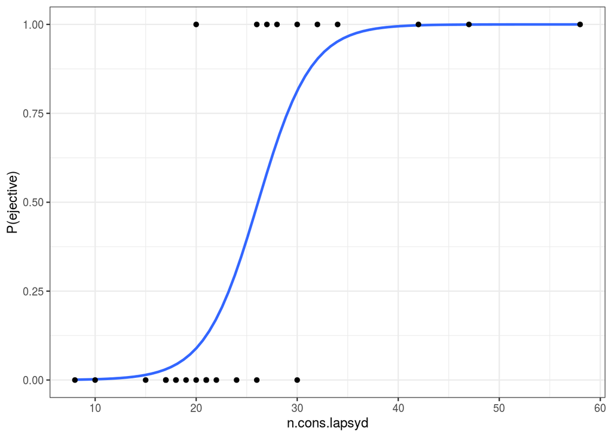

```r
ej_cons %>%
  mutate(`P(ejective)` = as.numeric(ejectives) - 1) %>%
  ggplot(aes(x = n.cons.lapsyd, y = `P(ejective)`))+
  geom_smooth(method = "glm", method.args = list(family = "binomial"), se = FALSE) +
  geom_point()+
  theme_bw()
```

So probability for a language that have 30 consonants will be
$$\log(odds(ej)) = -9.9204 + 0.3797 \times 30 = 1.4706$$

### 1.4 predict()

```r
new.df <- data.frame(n.cons.lapsyd = c(30, 55, 34, 10))
predict(fit2, new.df) # odds
```

```
##         1         2         3         4
##  1.470850 10.963579  2.989686 -6.123334
```

```r
predict(fit2, new.df, type = "response") # probabilities
```

```
##           1           2           3           4
## 0.813186486 0.999982679 0.952106011 0.002186347
```

```r
predict(fit2, new.df, type = "response", se.fit = TRUE) # probabilities and confidense interval
```

```
## $fit
##           1           2           3           4
## 0.813186486 0.999982679 0.952106011 0.002186347
##
## $se.fit
##            1            2            3            4
## 1.512886e-01 7.882842e-05 6.869366e-02 5.038557e-03
##
## $residual.scale
## [1] 1
```

So we actually can create a plot with confidense intervals.

```r
ej_cons_ci <- cbind.data.frame(ej_cons, predict(fit2, ej_cons, type = "response", se.fit = TRUE)[1:2])
ej_cons_ci
```

```
##          name n.cons.lapsyd ejectives         fit       se.fit
## 1     Turkish            24        no 0.308443627 1.376976e-01
## 2      Korean            21        no 0.124931874 9.358363e-02
## 3        Tiwi            21        no 0.124931874 9.358363e-02
## 4      Kpelle            22        no 0.172669632 1.090491e-01
## 5        Tulu            21        no 0.124931874 9.358363e-02
## 6  Mapudungun            20        no 0.088972775 7.806484e-02
## 7       Kiowa            19        no 0.062623081 6.341445e-02
## 8     Guarani            18        no 0.043702625 5.034610e-02
## 9    Japanese            15        no 0.014417525 2.278884e-02
## 10      Batak            17        no 0.030313786 3.921885e-02
## 11     Yoruba            18        no 0.043702625 5.034610e-02
## 12    Finnish            17        no 0.030313786 3.921885e-02
## 13  Kayardild            17        no 0.030313786 3.921885e-02
## 14   Hawaiian             8        no 0.001024268 2.658820e-03
## 15      Maori            10        no 0.002186347 5.038557e-03
## 16  Hungarian            26        no 0.488005505 1.637595e-01
## 17    Kannada            30        no 0.813186486 1.512886e-01
## 18   Georgean            28       yes 0.670717326 1.740778e-01
## 19     Ingush            34       yes 0.952106011 6.869366e-02
## 20     Abkhaz            58       yes 0.999994456 2.769836e-05
## 21    Amharic            32       yes 0.902934848 1.088031e-01
## 22    Sandawe            47       yes 0.999638868 1.216840e-03
## 23    Tlingit            42       yes 0.997593950 6.337117e-03
## 24     Lakota            30       yes 0.813186486 1.512886e-01
## 25    Yucatec            20       yes 0.088972775 7.806484e-02
## 26     Aymara            27       yes 0.582178309 1.725265e-01
## 27       Pomo            26       yes 0.488005505 1.637595e-01
```

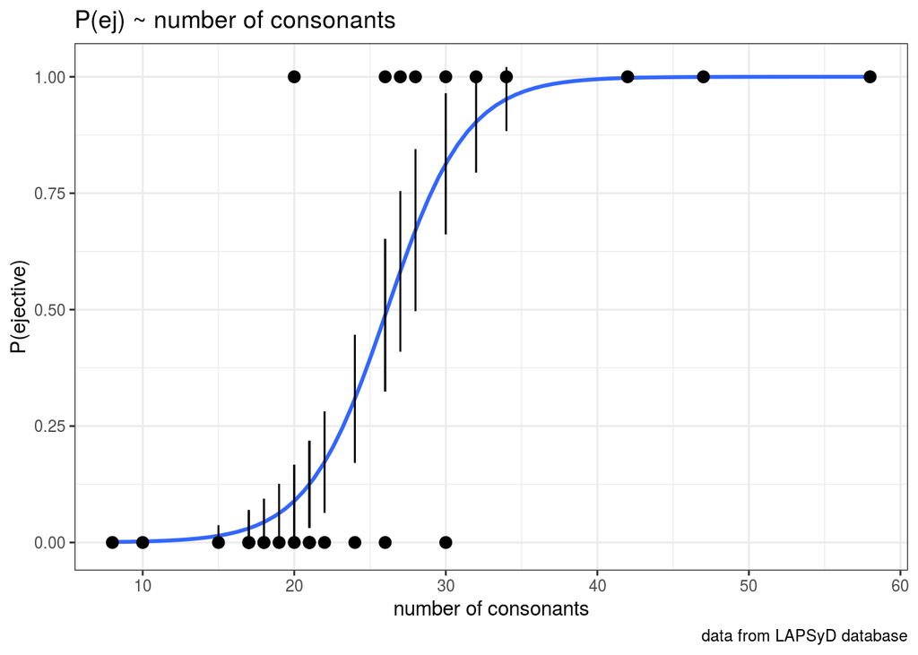

```r
ej_cons_ci %>%
  mutate(`P(ejective)` = as.numeric(ejectives) - 1) %>%
  ggplot(aes(x = n.cons.lapsyd, y = `P(ejective)`))+
  geom_smooth(method = "glm", method.args = list(family = "binomial"), se = FALSE)+
  geom_point() +
  geom_pointrange(aes(x = n.cons.lapsyd, ymin = fit - se.fit, ymax = fit + se.fit))+
  labs(title = "P(ej) ~ number of consonants",
       x = "number of consonants",
       caption = "data from LAPSyD database")+
  theme_bw()
```

## 2. Choice betweeen two constructions in Russian

The Russian verb *gruzit’* `load’ is special for three reasons. First, this verb has two syntactic constructions it can appear in, second, it has three perfective counterparts with the prefixes *NA-*, *PO-*, and *ZA-* that do not add to its lexical meaning (and thus can be cosidered Natural Perfectives), and third all three Natural Perfectives can also use both constructions.

The two constructions that *gruzit’* ‘load’ can appear in are called the ‘’THEME-object’’ construction and the ‘’GOAL-object’’ construction, and this phenomenon is known in many languages as Locative Alternation. We can illustrate these two constructions in Russian with the following examples:

- THEME-object: *gruzit’* *jaschiki*.ACC *na telegu*(PP) ‘load the boxes.THEME onto the cart.GOAL’. The goal appears in a prepositional phrase in the theme-object construction, usually with the preposition *na* `onto' or _v_`into’.
- GOAL-object: *gruzit’* *telegu*.ACC *jaschikami*.INS ‘load the cart.GOAL with boxes.THEME’. The theme in the GOAL-object construction appears in the instrumental case. *gruzit’*

The verb `load’ uses not just one, but three prefixes to form Natural Perfectives: *NA-*, *ZA-*, and *PO-*. Collectively we call these four verbs (the simplex and the three Natural Perfectives) ‘’the ’load’ verbs’’. All three Natural Perfectives can appear in both the THEME-object and the GOAL-object constructions. Janda et al. 2013, chapter 4 explores whether the choice of prefix makes a difference in the distribution of the THEME-object and GOAL-object constructions. Along with the prefixes, they test whether the passive construction (ie. construction with passive participle) and omission of the prepositional phrase (ie. reduced construction) could motivate the choice between the THEME-object and GOAL-object constructions.

The dataset: There are 1920 lines of data, each corresponding to one of the examples extracted from the Russian National Corpus. The dataset includes four variables:  
* CONSTRUCTION: This is our dependent variable, and it has two values, `theme`, and `goal`.  
* VERB: This is an independent variable, and it has four values, `\_zero` (for the unprefixed verb *gruzit’* ‘load’), `na`, `za`, and `po` (for the three prefixed variants).  
* REDUCED: This is an independent variable, and it has two values, yes and no. This refers to whether the construction was reduced (`yes`) or full (`no`).  
* PARTICIPLE: This is an independent variable, and it has two values, yes and no. This refers to whether the construction was passive (`yes`) or active (`no`).

Source: [Trolling repository](https://hdl.handle.net/10037.1/10022) References: Janda et al. (2013), Why Russian aspectual prefixes aren’t empty: prefixes as verb classifiers. Bloomington, IN: Slavica Publishers.

### 2.1 Data summary

```r
loaddata = read.csv('https://raw.githubusercontent.com/LingData2019/LingData/master/data/loaddata.csv')
summary(loaddata)
```

```
##  CONSTRUCTION    VERB     REDUCED    PARTICIPLE
##  goal : 871   _zero:393   no :1353   no : 895
##  theme:1049   na   :368   yes: 567   yes:1025
##               po   :703
##               za   :456
```

### 2.2 Formulate your hypothesis, what motivates the choice between two constructions?

### 2.3 Fit the simplest logistic regression model using `VERB` as the only factor.

```r
# use glm() in the following way: fit <- glm(Dependent_variable ~ Factor_variable(s), family = binomial, data = ....)
fit1 <- glm(CONSTRUCTION ~ VERB, loaddata, family = binomial)
summary(fit1)
```

```
##
## Call:
## glm(formula = CONSTRUCTION ~ VERB, family = binomial, data = loaddata)
##
## Deviance Residuals:
##     Min       1Q   Median       3Q      Max
## -3.3036  -0.7235   0.0925   0.0925   2.1692
##
## Coefficients:
##             Estimate Std. Error z value Pr(>|z|)
## (Intercept)   0.1274     0.1011   1.260    0.208
## VERBna       -2.3802     0.2044 -11.643   <2e-16 ***
## VERBpo        5.3251     0.5873   9.066   <2e-16 ***
## VERBza       -1.3342     0.1503  -8.877   <2e-16 ***
## ---
## Signif. codes:  0 '***' 0.001 '**' 0.01 '*' 0.05 '.' 0.1 ' ' 1
##
## (Dispersion parameter for binomial family taken to be 1)
##
##     Null deviance: 2645.2  on 1919  degrees of freedom
## Residual deviance: 1305.3  on 1916  degrees of freedom
## AIC: 1313.3
##
## Number of Fisher Scoring iterations: 8
```

### 2.5 Add more factors to your model, one by one.

Note that we do not consider possible interactions here yet.

```r
fit3 <- glm(CONSTRUCTION ~ VERB + REDUCED + PARTICIPLE, loaddata, family = "binomial")
summary(fit3)
```

```
##
## Call:
## glm(formula = CONSTRUCTION ~ VERB + REDUCED + PARTICIPLE, family = "binomial",
##     data = loaddata)
##
## Deviance Residuals:
##     Min       1Q   Median       3Q      Max
## -3.9999  -0.2447   0.0173   0.1116   3.0746
##
## Coefficients:
##               Estimate Std. Error z value Pr(>|z|)
## (Intercept)     1.2315     0.1513   8.137 4.07e-16 ***
## VERBna         -2.2183     0.2331  -9.515  < 2e-16 ***
## VERBpo          7.5756     0.6447  11.751  < 2e-16 ***
## VERBza         -0.9941     0.1842  -5.398 6.75e-08 ***
## REDUCEDyes     -0.8078     0.1728  -4.676 2.93e-06 ***
## PARTICIPLEyes  -3.7309     0.2900 -12.867  < 2e-16 ***
## ---
## Signif. codes:  0 '***' 0.001 '**' 0.01 '*' 0.05 '.' 0.1 ' ' 1
##
## (Dispersion parameter for binomial family taken to be 1)
##
##     Null deviance: 2645.16  on 1919  degrees of freedom
## Residual deviance:  928.19  on 1914  degrees of freedom
## AIC: 940.19
##
## Number of Fisher Scoring iterations: 8
```

### 2.6 Which model fits your data the best according to AIC?

Note that this model should include only significant factors.

AIC (Akaike Information Criterion) is a goodness-of-fit measure to compare the models with different number of predictors. It penalizes a model for having too many predictors. The smaller AIC, the better.

[output not shown]

Hint: Dependent_variable ~ Factor1 * Factor2 * Factor3 (the same as: Factor1 + Factor2 + Factor3 + Factor1:Factor2 + … + Factor1:Factor2:Factor3)

```r
fit7 <- glm(CONSTRUCTION ~ VERB + REDUCED + PARTICIPLE + VERB:PARTICIPLE, loaddata, family = "binomial")
summary(fit7)
```

```
##
## Call:
## glm(formula = CONSTRUCTION ~ VERB + REDUCED + PARTICIPLE + VERB:PARTICIPLE,
##     family = "binomial", data = loaddata)
##
## Deviance Residuals:
##     Min       1Q   Median       3Q      Max
## -3.1261  -0.2414   0.0790   0.0914   3.2058
##
## Coefficients:
##                      Estimate Std. Error z value Pr(>|z|)
## (Intercept)            1.3872     0.1616   8.584  < 2e-16 ***
## VERBna                -2.3336     0.2446  -9.539  < 2e-16 ***
## VERBpo                 4.3806     1.0118   4.330 1.49e-05 ***
## VERBza                -1.2416     0.1981  -6.267 3.68e-10 ***
## REDUCEDyes            -0.8891     0.1748  -5.085 3.67e-07 ***
## PARTICIPLEyes         -5.9579     1.0169  -5.859 4.66e-09 ***
## VERBna:PARTICIPLEyes   1.7717     1.4415   1.229 0.219043
## VERBpo:PARTICIPLEyes   5.6670     1.5926   3.558 0.000373 ***
## VERBza:PARTICIPLEyes   3.1804     1.0729   2.964 0.003034 **
## ---
## Signif. codes:  0 '***' 0.001 '**' 0.01 '*' 0.05 '.' 0.1 ' ' 1
##
## (Dispersion parameter for binomial family taken to be 1)
##
##     Null deviance: 2645.16  on 1919  degrees of freedom
## Residual deviance:  906.69  on 1911  degrees of freedom
## AIC: 924.69
##
## Number of Fisher Scoring iterations: 8
```

### 2.8 Remove all insignificant interactions and report the minimal optimal model here:

```r
CONSTRUCTION ~ VERB + REDUCED + PARTICIPLE + VERB:PARTICIPLE
```

```
## CONSTRUCTION ~ VERB + REDUCED + PARTICIPLE + VERB:PARTICIPLE
```

### 2.9 Check the 95% confidence intevals of the estimated coefficients.

Use confint(model_name) to calculate them.

```r
print("These are the confidence interval values:")
```

```
## [1] "These are the confidence interval values:"
```

```r
confint(fit7)
```

```
##                          2.5 %     97.5 %
## (Intercept)           1.077659  1.7120139
## VERBna               -2.825357 -1.8647411
## VERBpo                2.859036  7.2560372
## VERBza               -1.634089 -0.8567527
## REDUCEDyes           -1.235253 -0.5492324
## PARTICIPLEyes        -8.838291 -4.4202915
## VERBna:PARTICIPLEyes -1.494244  5.0379696
## VERBpo:PARTICIPLEyes  2.219574  9.1864343
## VERBza:PARTICIPLEyes  1.461953  6.1140973
```

If a 95% confidence interval contains zero, this indicates that the corresponding effect is not significant. You can also use `exp(confint(...))` to obtain simple odds ratios. The confidence interval of a significant effect based on simple odds ratios should not include 1.

We can plot this coefficients with confidence intervals at the same time. To do this we need the library `jtools` that requires `ggstance`:

```r
install.packages("ggstance")
install.packages("jtools")
```

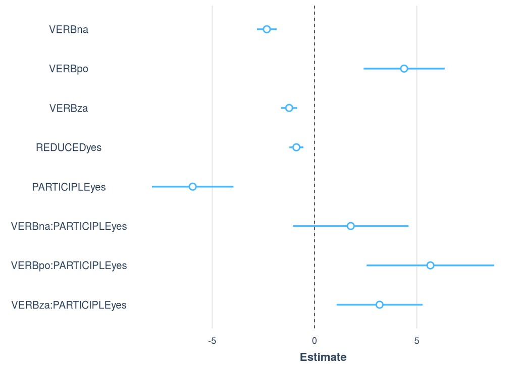

```r
library(jtools)
plot_summs(fit7)
```

### 2.10 Report the odds of success for each predictor variable.

Use exp(model_name$coefficients)

```r
print("These are the odds of success for each predictor variable:")
```

```
## [1] "These are the odds of success for each predictor variable:"
```

```r
tibble(exp(fit7$coefficients))
```

```
## # A tibble: 9 x 1
##   `exp(fit7$coefficients)`
##                      <dbl>
## 1                  4.00
## 2                  0.0969
## 3                 79.9
## 4                  0.289
## 5                  0.411
## 6                  0.00259
## 7                  5.88
## 8                289.
## 9                 24.1
```

### 2.11 Additional code: stepwise selection of variables

See examples from Levshina 2015: m0.glm <- glm(Aux ~ 1, data = doenLaten, family = binomial) m.fw <- step(m0.glm, direction = “forward”, scope = ~ Causation + EPTrans + Country)

m.glm <- glm(Aux ~ Causation + EPTrans + Country, data = doenLaten, family = binomial) m.bw <- step(m.glm, direction = “backward”)

```r
load.glm0 <- glm(CONSTRUCTION ~ 1, family=binomial, data=loaddata)
load.glm.fw <- step(load.glm0, direction = "forward", scope = ~ VERB + REDUCED + PARTICIPLE)
```

```
## Start:  AIC=2647.16
## CONSTRUCTION ~ 1
##
##              Df Deviance    AIC
## + VERB        3   1305.3 1313.3
## + REDUCED     1   2470.5 2474.5
## + PARTICIPLE  1   2559.9 2563.9
## <none>            2645.2 2647.2
##
## Step:  AIC=1313.31
## CONSTRUCTION ~ VERB
##
##              Df Deviance     AIC
## + PARTICIPLE  1   950.73  960.73
## + REDUCED     1  1291.51 1301.51
## <none>           1305.31 1313.31
##
## Step:  AIC=960.73
## CONSTRUCTION ~ VERB + PARTICIPLE
##
##           Df Deviance    AIC
## + REDUCED  1   928.19 940.19
## <none>         950.73 960.73
##
## Step:  AIC=940.19
## CONSTRUCTION ~ VERB + PARTICIPLE + REDUCED
```

```r
load.glm2 <- glm(CONSTRUCTION ~ ., family=binomial, data=loaddata)
load.glm.bw <- step(load.glm2, direction = "backward")
```

```
## Start:  AIC=940.19
## CONSTRUCTION ~ VERB + REDUCED + PARTICIPLE
##
##              Df Deviance     AIC
## <none>            928.19  940.19
## - REDUCED     1   950.73  960.73
## - PARTICIPLE  1  1291.51 1301.51
## - VERB        3  2353.91 2359.91
```

### 2.12 Additional code: variables’ importance

```r
library(caret)
varImp(load.glm2)
```

```
##                 Overall
## VERBna         9.514942
## VERBpo        11.751458
## VERBza         5.397603
## REDUCEDyes     4.675675
## PARTICIPLEyes 12.867231
```

### 2.13 Model accuracy

#### Dividing data into training and test sets

The rule of thumb is to use 10% or 20% or 25% data points as a test set (usually not less than 20 data points). The model will be trained on the remaining data.

```r
set.seed(42)
load.test.index <- sample(1:nrow(loaddata), size=floor(nrow(loaddata)/10)) # select 10% random points, this will create a vector
paste0("The test set size: ", floor(nrow(loaddata)/10), ". The training set size: ", nrow(loaddata)-floor(nrow(loaddata)/10), ".")
```

```
## [1] "The test set size: 192. The training set size: 1728."
```

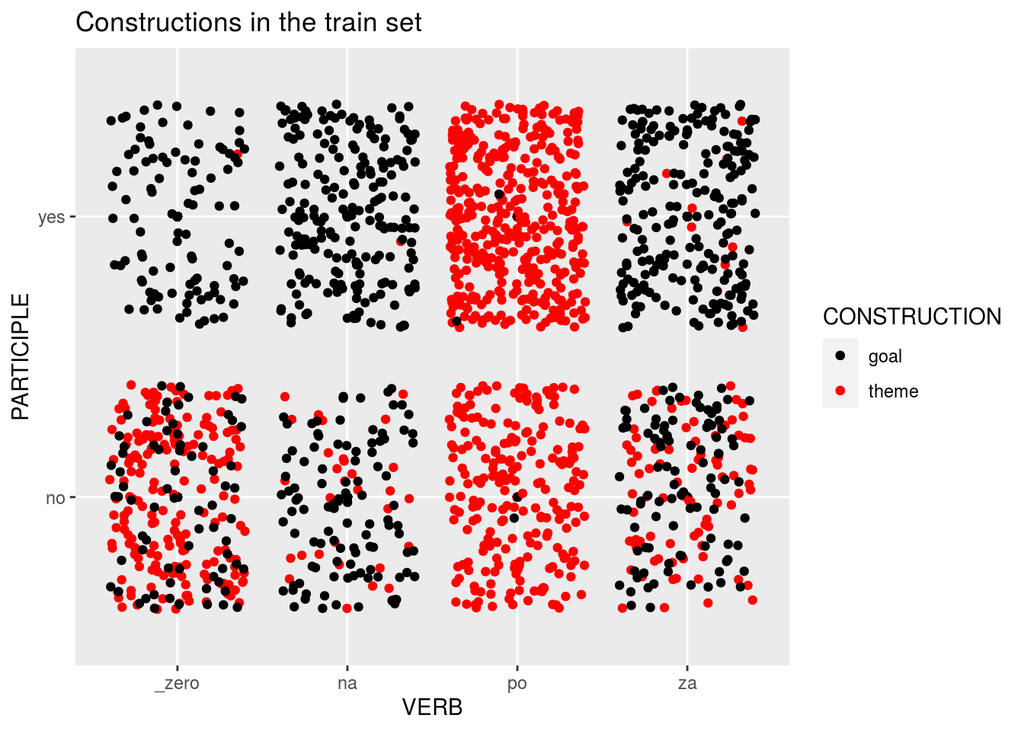

```r
load.test <- loaddata[load.test.index,]
load.train <- loaddata[-load.test.index,]
load.train %>%
  ggplot(aes(x=VERB, y=PARTICIPLE, col=CONSTRUCTION)) +
  scale_color_manual(values=c("black", "red")) +
  geom_point() +
  geom_jitter() +
  ggtitle("Constructions in the train set")
```

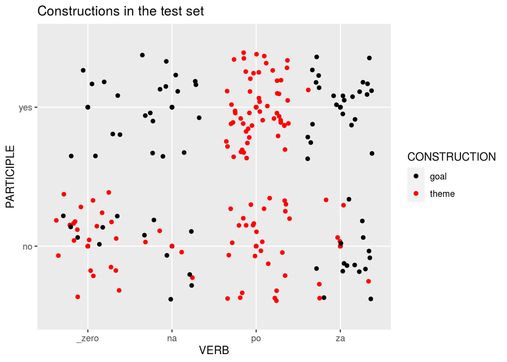

```r
load.test %>%
  ggplot(aes(x=VERB, y=PARTICIPLE, col=CONSTRUCTION)) +
  scale_color_manual(values=c("black", "red")) +
  geom_point() +
  geom_jitter() +
  ggtitle("Constructions in the test set")
```

- Training the model on the train set, making prediction on the test set

```r
load.glm5 <- glm(CONSTRUCTION ~ VERB + REDUCED + PARTICIPLE + VERB:PARTICIPLE, family="binomial", data=load.train)
#print(summary(load.glm5))
load.glm5.link.scores <- predict(load.glm5, newdata=load.test, type="link")
load.glm5.response.scores <- predict(load.glm5, newdata=load.test, type="response")
load.glm5.scores <- data.frame(link=load.glm5.link.scores,
                         response=load.glm5.response.scores,
                         construction_obs=load.test$CONSTRUCTION,
                         stringsAsFactors=FALSE)
```

#### Confusion matrix and accuracy

Confusion matrix counts the cases of correctly predicted classes as well as the cases of misclassification (false positives and false negatives) . **Accuracy** are the counts on the backslash diagonal divided by the total counts.

```r
load.test %>%
  count(CONSTRUCTION, VERB, REDUCED, PARTICIPLE) %>%
  select(-n, -CONSTRUCTION) %>%
  unique() ->
  load.test.pdata

load.test.pdata %>%
  predict(load.glm5, newdata = ., type = "response") ->
  load.test.pdata$PREDICTION

load.test.pdata %>%
  arrange(PREDICTION)
```

```
## # A tibble: 15 x 4
##    VERB  REDUCED PARTICIPLE PREDICTION
##    <fct> <fct>   <fct>           <dbl>
##  1 na    yes     yes           0.00273
##  2 na    no      yes           0.00629
##  3 _zero no      yes           0.0111
##  4 za    yes     yes           0.0299
##  5 za    no      yes           0.0665
##  6 na    yes     no            0.134
##  7 na    no      no            0.263
##  8 za    yes     no            0.341
##  9 za    no      no            0.544
## 10 _zero yes     no            0.621
## 11 _zero no      no            0.792
## 12 po    yes     yes           0.989
## 13 po    yes     no            0.992
## 14 po    no      yes           0.995
## 15 po    no      no            0.996
```

```r
load.test.pdata %>%
  arrange(desc(PREDICTION))
```

```
## # A tibble: 15 x 4
##    VERB  REDUCED PARTICIPLE PREDICTION
##    <fct> <fct>   <fct>           <dbl>
##  1 po    no      no            0.996
##  2 po    no      yes           0.995
##  3 po    yes     no            0.992
##  4 po    yes     yes           0.989
##  5 _zero no      no            0.792
##  6 _zero yes     no            0.621
##  7 za    no      no            0.544
##  8 za    yes     no            0.341
##  9 na    no      no            0.263
## 10 na    yes     no            0.134
## 11 za    no      yes           0.0665
## 12 za    yes     yes           0.0299
## 13 _zero no      yes           0.0111
## 14 na    no      yes           0.00629
## 15 na    yes     yes           0.00273
```

```r
v <- rep(NA, nrow(load.glm5.scores))
v <- ifelse(load.glm5.scores$response >= .5, "theme", "goal")
load.glm5.scores$construction_pred <- as.factor(v)

confusionMatrix(data = load.glm5.scores$construction_pred, reference = load.glm5.scores$construction_obs, positive="theme")
```

```
## Confusion Matrix and Statistics
##
##           Reference
## Prediction goal theme
##      goal    63     8
##      theme   12   109
##
##                Accuracy : 0.8958
##                  95% CI : (0.8437, 0.9352)
##     No Information Rate : 0.6094
##     P-Value [Acc > NIR] : <2e-16
##
##                   Kappa : 0.7791
##
##  Mcnemar's Test P-Value : 0.5023
##
##             Sensitivity : 0.9316
##             Specificity : 0.8400
##          Pos Pred Value : 0.9008
##          Neg Pred Value : 0.8873
##              Prevalence : 0.6094
##          Detection Rate : 0.5677
##    Detection Prevalence : 0.6302
##       Balanced Accuracy : 0.8858
##
##        'Positive' Class : theme
##
```

#### Inspect false positives and false negatives

```r
data.frame(load.test, response = load.glm5.scores$response, predicted = load.glm5.scores$construction_pred)[load.glm5.scores$construction_pred != load.glm5.scores$construction_obs,] %>%
  arrange(predicted, response)
```

```
##    CONSTRUCTION  VERB REDUCED PARTICIPLE  response predicted
## 1         theme    za     yes        yes 0.0298797      goal
## 2         theme    na     yes         no 0.1338595      goal
## 3         theme    na      no         no 0.2634760      goal
## 4         theme    na      no         no 0.2634760      goal
## 5         theme    na      no         no 0.2634760      goal
## 6         theme    za     yes         no 0.3405532      goal
## 7         theme    za     yes         no 0.3405532      goal
## 8         theme    za     yes         no 0.3405532      goal
## 9          goal    za      no         no 0.5444937     theme
## 10         goal    za      no         no 0.5444937     theme
## 11         goal    za      no         no 0.5444937     theme
## 12         goal    za      no         no 0.5444937     theme
## 13         goal    za      no         no 0.5444937     theme
## 14         goal    za      no         no 0.5444937     theme
## 15         goal _zero     yes         no 0.6212790     theme
## 16         goal _zero     yes         no 0.6212790     theme
## 17         goal _zero     yes         no 0.6212790     theme
## 18         goal _zero     yes         no 0.6212790     theme
## 19         goal _zero     yes         no 0.6212790     theme
## 20         goal _zero      no         no 0.7915440     theme
```

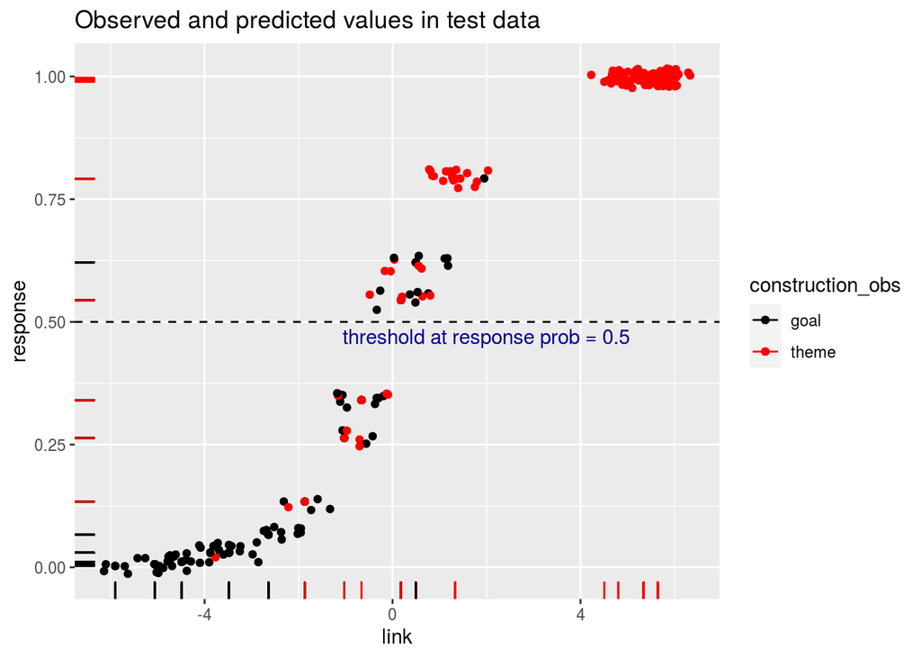

```r
load.glm5.scores %>%
  ggplot(aes(x=link, y=response, col=construction_obs)) +
  scale_color_manual(values=c("black", "red")) +
  geom_point() +
  geom_rug() +
  geom_jitter(width=.7, height=.02) +
  geom_hline(yintercept=0.5, linetype="dashed") +
  annotate(geom="text", x=2, y=0.47, label="threshold at response prob = 0.5", color="darkblue") +
  ggtitle("Observed and predicted values in test data")
```

Yet another way to plot observed and predicted variables:

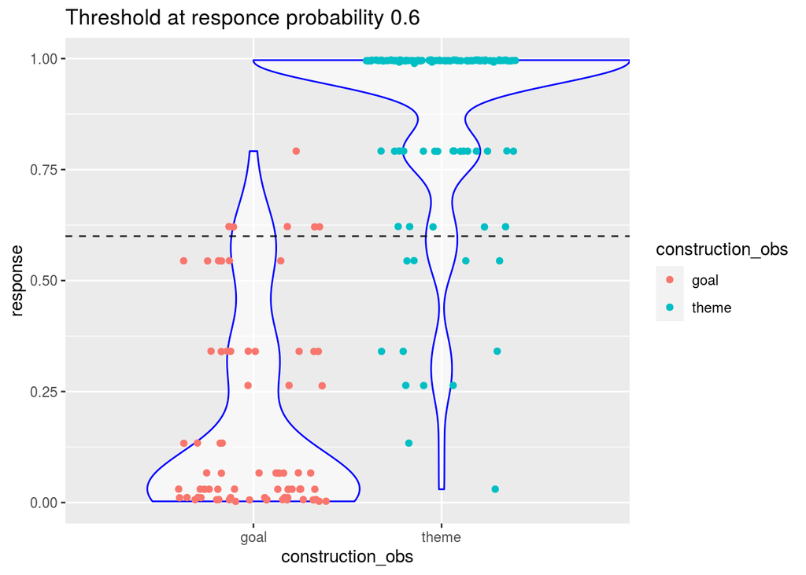

```r
  ggplot(data=load.glm5.scores, aes(x=construction_obs, y=response)) +
    geom_violin(fill=rgb(1,1,1,alpha=0.6), color="blue", width = 2) +
    geom_jitter(aes(color = construction_obs)) +
    geom_hline(yintercept=0.6, linetype="dashed", alpha=0.8) +
#    scale_color_discrete(name = "type") +
    labs(title="Threshold at responce probability 0.6")
```

### 2.14 AUC (area under the ROC curve)

The area under the ROC curve (AUC) ranges from 0.50 to 1.00, where 0.50 is considered a random prediction, 0.70 is a borderline case, and 0.80 and above indicates that the model does a good job in discriminating between the two output values. The closer the ROC gets to the optimal point of perfect prediction in the top left corner the closer the AUC gets to 1.  
*ROC stands for Receiver Operating Characteristics. Read more: https://www.r-bloggers.com/illustrated-guide-to-roc-and-auc/.

```r
load.glm5.roc <- roc(load.test$CONSTRUCTION, load.glm5.response.scores, direction="<")
```

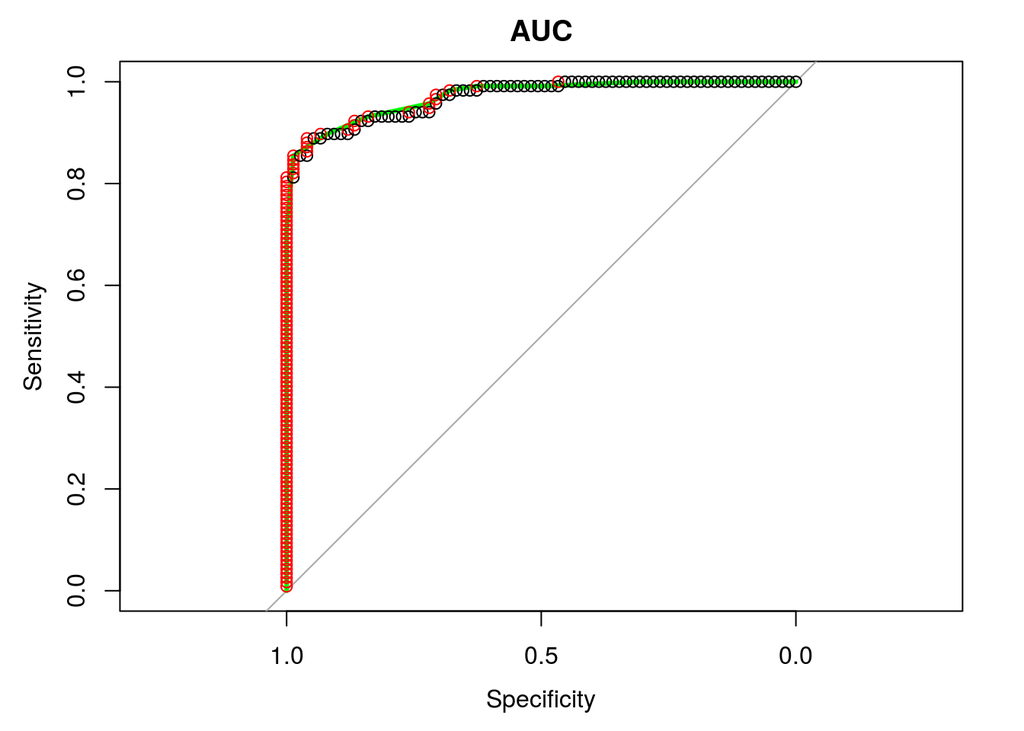

```r
plot(load.glm5.roc, col="green", lwd=3, main="AUC")

simple_roc <- function(labels, scores){
  labels <- labels[order(scores, decreasing=TRUE)]
  data.frame(TPR=cumsum(labels)/sum(labels), FPR=cumsum(!labels)/sum(!labels), labels)
} #TPR - True Positive Ratio, FPR - False Positive Ratio
load.glm5.simple.roc <- simple_roc(load.test$CONSTRUCTION=="theme", load.glm5.link.scores)
with(load.glm5.simple.roc, points(1 - FPR, TPR, col=1 + labels))
```

```r
auc(load.glm5.roc)
```

```
## Area under the curve: 0.9715
```